# ADD2 - DM Causalité

OSMAN Ahmed & OUOROU Rachidou

## Exercice 1

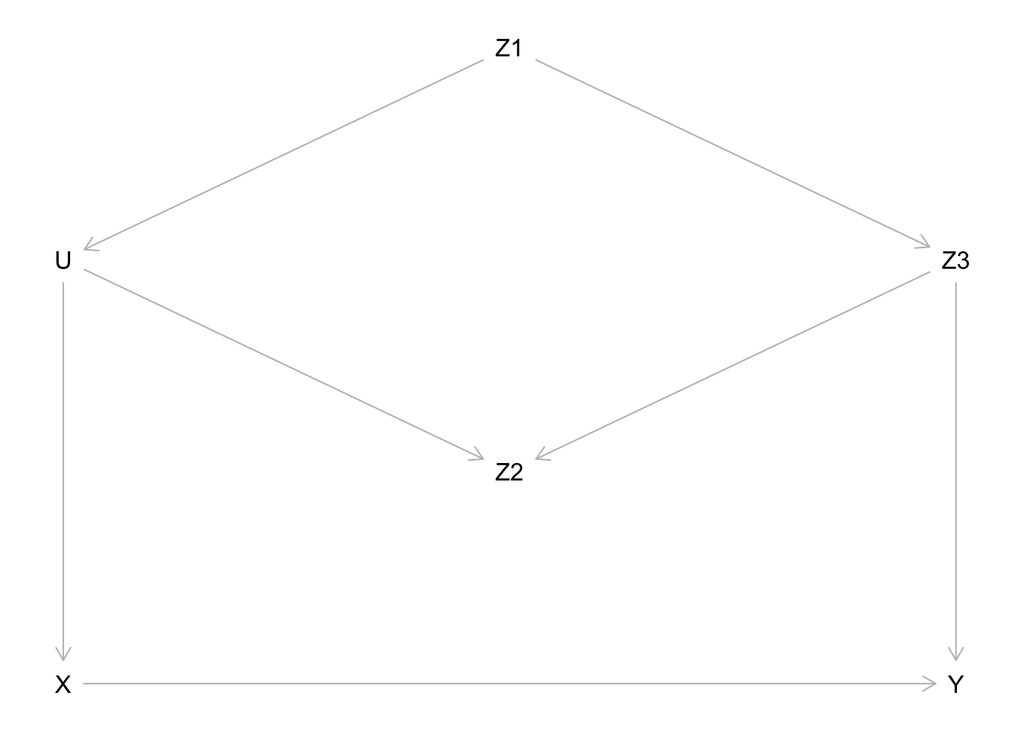

### question 1

Liste de tous les chemins entre X et Y :

- X -> Y : chemin **ouvert**
- X <- U -> Z2 <- Z3 -> Y : chemin **fermé**
- X <- U <- Z1 -> Z3 -> Y : chemin **ouvert**

Les chemins ouverts entre X et Y sont donc :

**X -> Y** et **X <- U <- Z1 -> Z3 -> Y**

```r
paths(d, from = "X", to = "Y")
```

```
## $paths
## [1] "X -> Y"                  "X <- U -> Z2 <- Z3 -> Y"
## [3] "X <- U <- Z1 -> Z3 -> Y"
##
## $open
## [1]  TRUE FALSE  TRUE
```

### question 2

Il faut bloquer **X <- U <- Z1 -> Z3 -> Y**

En bloquant ce chemin, toutes les confusions ont été supprimées car il n’y a pas de chemin backdoor ouverts entre X et Y.

### question 3

Non, car on a X -> Y qui est un chemin frontdoor et donc un chemin causal, mais ce n’est pas le seul, on voudrait donc le rendre unique (frontdoor et ouvert).

Il faut conditionner sur **Z3** ou **Z1** pour bloqué le chemin frontdoor **Z1 -> Z3 -> Y**.

```r
latents(d) = "U"
adjustmentSets(d, exposure = "X", outcome = "Y")
```

```
## { Z3 }
## { Z1 }
```

### question 4

On bloque les chemins Backddor :

**X <- U -> Z2 <- Z3 -> Y** est un chemin Backdoor fermé, donc on conditionnant sur U ou Z3 le chemin reste fermé à cause de Z2.

**X <- U <- Z1 -> Z3 -> Y** est un chemin Backdoor ouvert, donc on conditionnant sur U ou Z3 ou Z1 le chemin sera fermé.

Ainsi les ensembles d’ajustement sont {Z3}, {Z1}, {U}.

```r
# Vérification
d <- dagitty(
  'dag{
    X [pos = "0, 0"]
    U [pos = "0, -1"]
    Z1 [pos = "1, -1.5"]
    Z2 [pos = "1, -0.5"]
    Z3 [pos = "2, -1"]
    Y [pos = "2, 0"]
    Z1 -> U -> Z2
    Z1 -> U -> X -> Y
    Z1 -> Z3 -> Z2
    Z1 -> Z3 -> Y
    X -> Y
  }'
)

adjustmentSets(d, exposure = "X", outcome = "Y")
```

```
## { Z3 }
## { Z1 }
## { U }
```

## Exercice 2

### question 1

```r
set.seed(42)

n <- 1000

# Epsilon
epsU <- rnorm(n, 0, sqrt(0.5))
epsX <- rnorm(n, 0, sqrt(0.5))
epsR <- rnorm(n, 0, sqrt(0.5))
epsV <- rnorm(n, 0, sqrt(0.5))
epsZ <- rnorm(n, 0, sqrt(0.5))
epsW <- rnorm(n, 0, sqrt(0.5))
epsY <- rnorm(n, 0, sqrt(0.5))

U <- 1 + epsU
X <- U + epsX

R <- 2 + epsR
V <- U + R + epsV

Z <- X + epsZ
W <- Z + 2*X + epsW
Y <- 2*V + W + R + epsY
```

### question 2

Oui, X a un effet causal sur Y, car les chemins de X vers Y sont causals (chemins front-door ouvert)

### question 3

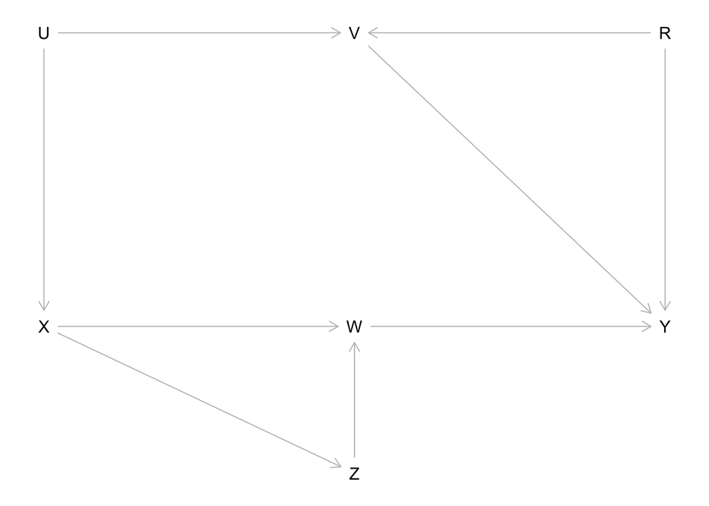

En introduisant l’opérateur **do(X=x)**, le schéma devient :

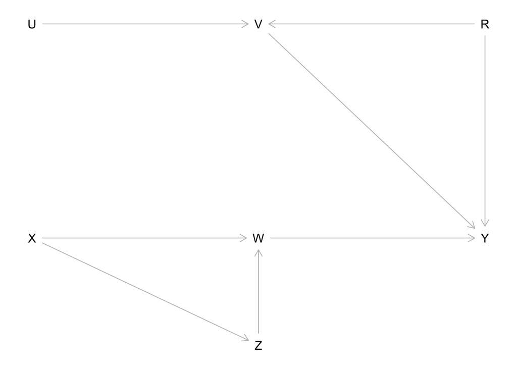

L’expression de la loi de probabilité jointe est donc :

$$\mathbb{F}(U=u, R=r, V=v, Z=z, W=w, Y=y|\ do(X=x))=\\F(R=r). F(U=u).F(V=v | R=r, U=u)\\.F(W=w | X=x, Z=z).F(Z=z|X=x).F(Y=y|R=r, V=v, W=w)$$

### question 4

$$\mathbb{F}(Y=y|\ do(X=x))= \int_{u}\int_{v}\int_{r}\int_{w}\int_{z} F(R=r). F(V=v).F(V=v | R=r, U=u)\\.F(W=w | X=x, Z=z).F(Z=z|X=x).F(Y=y|R=r, V=v, W=w)\ \mathrm{d}u \ \mathrm{d}v \ \mathrm{d}r\ \mathrm{d}w \ \mathrm{d}z$$

### question 5

```r
do.x_0 = rep(0, 1000)
do.x_1 = rep(1, 1000)

Z0 = do.x_0 + epsZ
W0 = Z0 + 2*do.x_0 + epsW
Y_do_0 = 2*V + W0 + R + epsY


Z1 = do.x_1 + epsZ
W1 = Z1 + 2*do.x_1 + epsW
Y_do_1 = 2*V + W1 + R + epsY
```

### question 6

```r
mean(Y_do_1 - Y_do_0)
```

```
## [1] 3
```

### question 7

```r
adjustmentSets(d, exposure = "X", outcome = "Y")
```

```
## { R, V }
## { U }
```

On bloque les chemins Backddor :

**X <- U -> V <- R -> Y** est un chemin Backdoor fermé, donc on conditionnant sur V on l’ouvre et en reconditionnant sur R on le ferme. On pouvait aussi conditionner que sur U et le chemin restera fermé. Ainsi l’ensemble d’ajustement est {R, V} et {U}.

Pareil pour **X <- U -> V -> Y**

### question 8

Lorsque {U} est l’ensemble d’ajustement :

$$\mathbb{F}(Y=y|\ do(X=x))=\int_{u} F(U=u).F(Y=y|R=r, V=v, W=w)\ \mathrm{d}u$$

Lorsque {V, R} est l’ensemble d’ajustement :

$$\mathbb{F}(Y=y|\ do(X=x))=\int_{v}\int_{r}\ F(R=r, V=v).F(Y=y|R=r, V=v, X=x)\ \mathrm{d}v \ \mathrm{d}r\$$

### question 9

```r
lm(Y~X)
```

```
##
## Call:
## lm(formula = Y ~ X)
##
## Coefficients:
## (Intercept)            X
##       6.917        4.031
```

```r
mean(Y_do_1 - Y_do_0)
```

```
## [1] 3
```

En faisant un régression de Y en fonction de X seulement on trouve que le coefficient de X est proche de 4 qui est différent de 3 (l’effet causale moyen trouvé à la question 6), ce qui n’est pas la vrai valeur de l’effet causale (effet causale biaisée).

```r
lm(Y~X+U)
```

```
##
## Call:
## lm(formula = Y ~ X + U)
##
## Coefficients:
## (Intercept)            X            U
##       6.000        3.070        1.891
```

```r
lm(Y~X+V+R)
```

```
##
## Call:
## lm(formula = Y ~ X + V + R)
##
## Coefficients:
## (Intercept)            X            V            R
##     -0.1488       2.9922       2.0202       1.0483
```

On trouve que les valeur des coefficients de X sont proche de 3 (l’effet causale moyen de la question 6), donc cela implique que {V, R} et {U} sont bien des ensembles d’ajustements qui va permettre d’identifier l’effet causale de X -> Y.

## Exercice 3

1- La relation d’indépendance (1) suit du fait que les chemins du type Z -> A -> W et Z -> Y -> W sont bloqués par A. Donc Z et indépendant de W en conditionnant par A.

2- Y est indépendant de A en conditionnant sur (W, Z) ou encore en conditionnant sur (W, Z) on bloque les chemins suivant :

- **A -> W -> Y**
- **A <- Z -> Y**

3- l’égalité (3) s’obtient du fait que :

$$\text{loi jointe : } \ \ P(Y, A, Z, W) = P(Z).P(A|Z).P(W|A).P(Y|W,Z) \\
\text{application de l'opérateur do() : } \mathbb{P}(Y, Z, W|do(A=a)) = P(Z).P(W|A=a).P(Y|W,Z) \\
\text{En passant par les probas totales : } \mathbb{P}(Y|do(A=a)) = \sum_{z,w} P(Z).P(W|A=a).P(Y|W,Z)$$

4- l’égalité (4) s’obtient du fait que :

$$\sum_{z} P(Z=z).P(W=w|A=a).P(Y=y|W=w,Z=z) \\
\text{En appliquant les probas totales on obtient : } \ \ \sum_{z, a'} P(z, a').P(y|z,w)$$

5- l’égalité (5) s’obtient du fait que : en appliquant les probas conditionnelles on a,

$$\sum_{z, a'} P(a').P(z|a').P(y|z, w)$$
6- l’égalité (6) s’obtient du fait que : en appliquant l’ignorabilité conditionnelles on a,

$$\sum_{z, a'} P(a').P(z|a', w).P(y|a', z, w)$$

7- l’égalité (7) s’obtient du fait que : en appliquant l’inverse des probas conditionnelles on a,

$$\sum_{z, a'} P(a').P(z, y|a', w)$$
8 - l’égalité (8) s’obtient du fait que : en appliquant l’inverse des probas conditionnelles on a,

$$\sum_{a'} P(a').P(y|a', w) = \sum_{a'} P(y,a'|w)$$